# DS 4100 Final Project

LetsRun.com Forum Forecasting

William Reed

# Data Acquisition

All of the inital data was obtained through a python web scraper and inserted into a MySQL database. In the database, post categories are stored with a numeric code. The translations of these codes to their actual name were manually created in a CSV file and will be inserted into a seperate table below for later JOIN commands.

### Connecting to the MySQL Server

```r
library(RMySQL)
con <- dbConnect(MySQL(),
         user="root", password=".",
         dbname="letsrun", host="localhost")
```

### Posts per day

Run some SQL to get the count of posts per day.

```r
posts_per_day <- dbGetQuery(con, "SELECT count(*) as count, date(datestamp) as date FROM posts GROUP BY date(datestamp);")
dbDisconnect(con)
```

```
## [1] TRUE
```

```r
posts_per_day
```

| count | date |
| --- | --- |
| 1 | 1985-07-27 |
| 62 | 2002-07-02 |
| 122 | 2002-07-03 |
| 69 | 2002-07-04 |
| 124 | 2002-07-05 |
| 78 | 2002-07-06 |
| 49 | 2002-07-07 |
| 157 | 2002-07-08 |
| 121 | 2002-07-09 |
| 111 | 2002-07-10 |

[output cut: 5729 more lines]

# Data Exploration

## Exploratory data plots

Some plots to help visualize the data. Mainly focused with posting rates so that data will be explored. ### Post per day

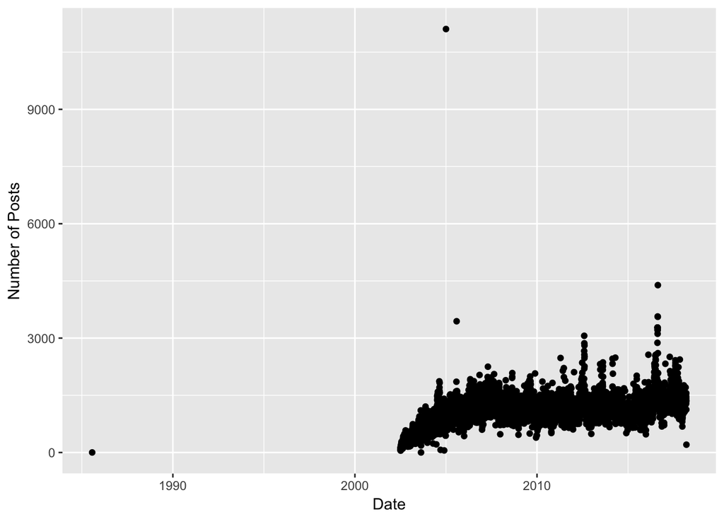

```r
library(ggplot2)
posts_per_day$date <- as.Date(posts_per_day$date)
qplot(x=date, y=count, data=posts_per_day, xlab = "Date", ylab = "Number of Posts")
```

```r
posts_per_day <- posts_per_day[!(posts_per_day$date == "1985-07-27"),]
```

Now to view the extreme outliers we can use the following

```r
head(posts_per_day[order(posts_per_day$count, decreasing = TRUE),], n = 20)
```

|  | count | date |
| --- | --- | --- |
| 916 | 11106 | 2005-01-01 |
| 5166 | 4389 | 2016-08-21 |
| 5162 | 3567 | 2016-08-17 |
| 5165 | 3559 | 2016-08-20 |
| 1129 | 3442 | 2005-08-02 |
| 5160 | 3278 | 2016-08-15 |
| 5157 | 3277 | 2016-08-12 |
| 5164 | 3269 | 2016-08-19 |
| 5159 | 3217 | 2016-08-14 |
| 5163 | 3214 | 2016-08-18 |

[output cut: 10 more lines]

#### Fixing ‘2005-01-01’

```r
# get average of 5 days before and after
ten_day <- posts_per_day[posts_per_day$date >= "2004-12-27" & posts_per_day$date <= "2005-01-06" & posts_per_day$date != "2005-01-01",]
ten_day_average <- as.integer(mean(ten_day$count))
posts_per_day[posts_per_day$date == "2005-01-01", "count"] <- ten_day_average
```

#### Fixing ‘2005-08-02’

```r
# get average of 10 days surrounding and set it
ten_day <- posts_per_day[posts_per_day$date >= "2005-07-23" & posts_per_day$date <= "2005-08-01",]
ten_day_average <- as.integer(mean(ten_day$count))
posts_per_day[posts_per_day$date == "2005-08-02", "count"] <- ten_day_average
```

#### Removing incomplete data

Only take complete years of data so take 2003 through 2017 only.

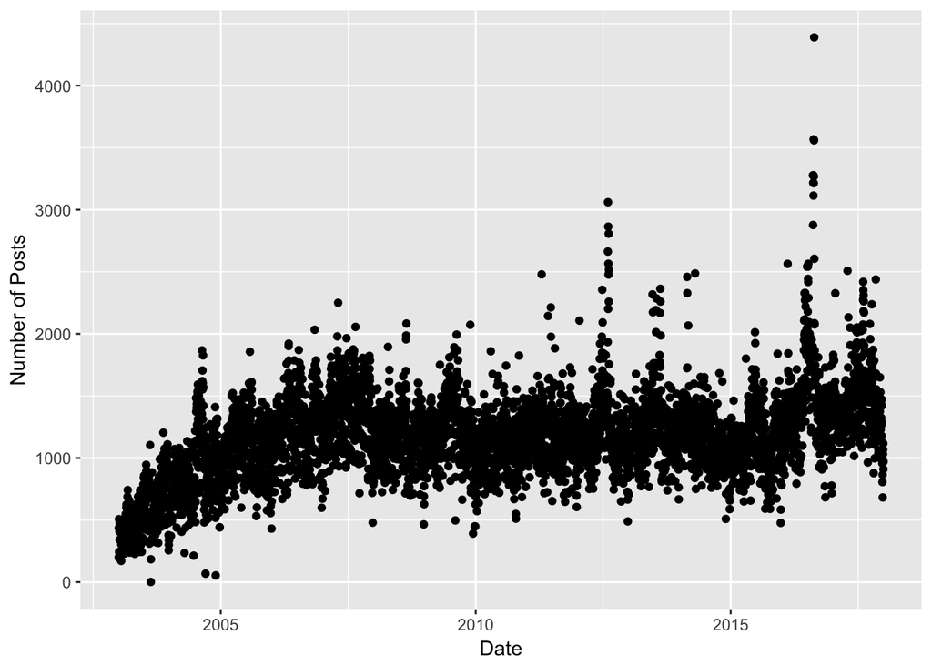

```r
posts_per_day <- posts_per_day[posts_per_day$date >= "2003-01-01" & posts_per_day$date < "2018-01-01",]
qplot(x=date, y=count, data=posts_per_day, xlab = "Date", ylab = "Number of Posts")
```

After cleaning the data a bit we can see a much clearer picture of what the usage of the site looks like. At first glance you may say those seemingly vertical lines are an outlier however those two lines represent the Olympics in 2012 and 2016, and such an increase in site usage is expected.

### Posts per month and year

To simplify the data further lets take a look at the posts per month. This is essentially a moving average for each month of data.

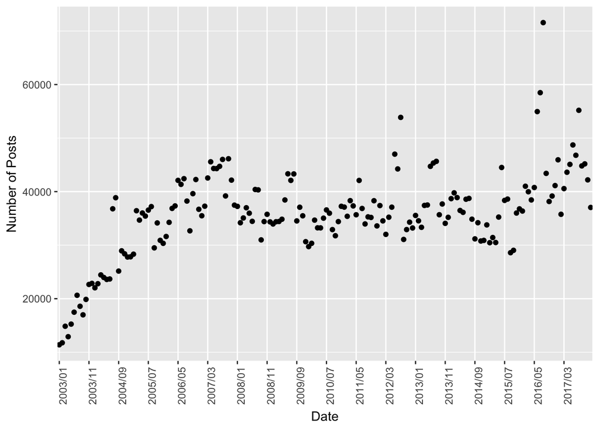

```r
month.year <- strftime(posts_per_day$date, "%Y/%m")
posts_per_month_year <- aggregate(posts_per_day$count ~ month.year, FUN = sum)
posts_per_month_year <- setNames(posts_per_month_year, c("month.year", "count"))
lvls <- posts_per_month_year$month.year
ggplot(posts_per_month_year, aes(x=month.year, y=count)) + geom_point() + xlab("Date") + ylab("Number of Posts") + theme(axis.text.x = element_text(angle = 90, hjust = 1))  + scale_x_discrete(breaks=lvls[seq(1,length(lvls),by=10)])
```

### Posts per month

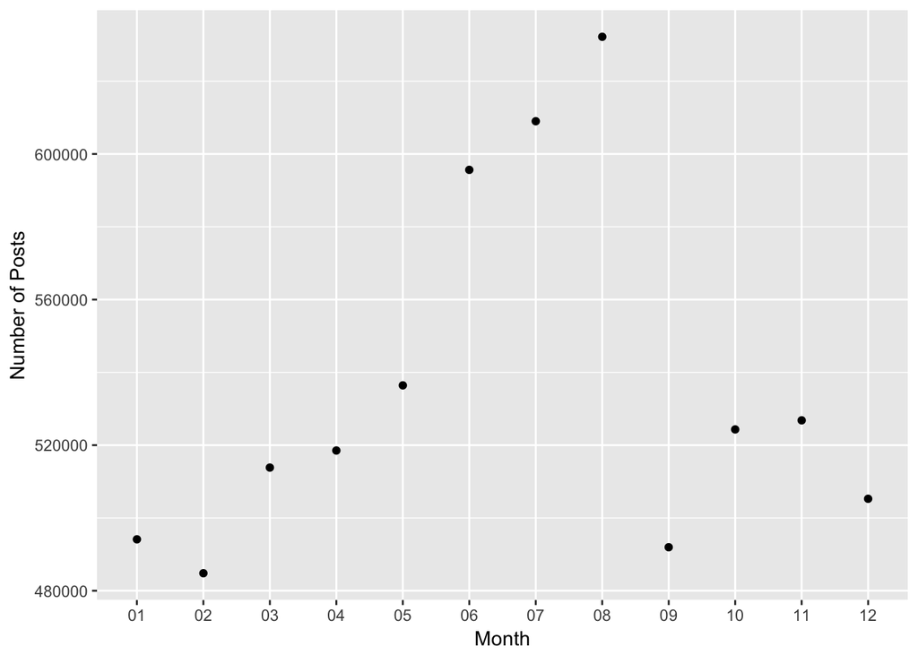

```r
month <- strftime(posts_per_day$date, "%m")
posts_per_month <- aggregate(posts_per_day$count ~ month, FUN = sum)
posts_per_month <- setNames(posts_per_month, c("month", "count"))
qplot(x=month, y=count, data=posts_per_month, xlab="Month", ylab = "Number of Posts")
```

This is a very interesting graph as it suggests a strong seasonality aspect to the usage of the site likely linked to the prevalence of the outdoor track season and global track events such as the Olympics and World Championships.

### Posts per day

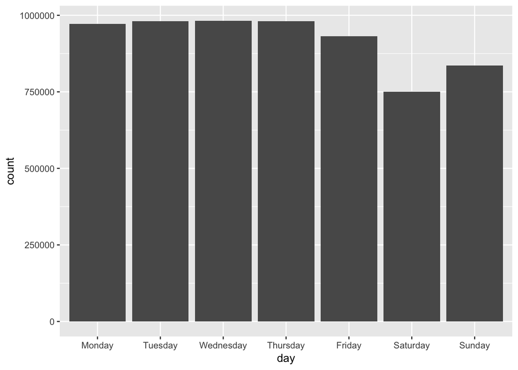

```r
day <- strftime(posts_per_day$date, "%A")
posts_per_day_total <- aggregate(posts_per_day$count ~ day, FUN = sum)
posts_per_day_total <- setNames(posts_per_day_total, c("day", "count"))
posts_per_day_total$day <- as.character(posts_per_day_total$day)
# reorder to fix the days being alphebetical
posts_per_day_total <- posts_per_day_total[c(2,6,7,5,1,3,4),]
posts_per_day_total <- data.frame(day=posts_per_day_total$day, count=posts_per_day_total$count)

ggplot(posts_per_day_total, aes(x=day, y=count)) + geom_histogram(stat="identity") + scale_x_discrete(limits=posts_per_day_total$day)
```

While this analysis won’t be concerned with prediction at this level it is interesting to node that the popularity of the site is the greatest on the week days.

## Models

#### ARIMA

This guide along with the wikipedia article on ARIMA were used to aid in learning how to use the model. https://www.datascience.com/blog/introduction-to-forecasting-with-arima-in-r-learn-data-science-tutorials An ARIMA model will be fitted to previous time series data and be used to forecast future site usage

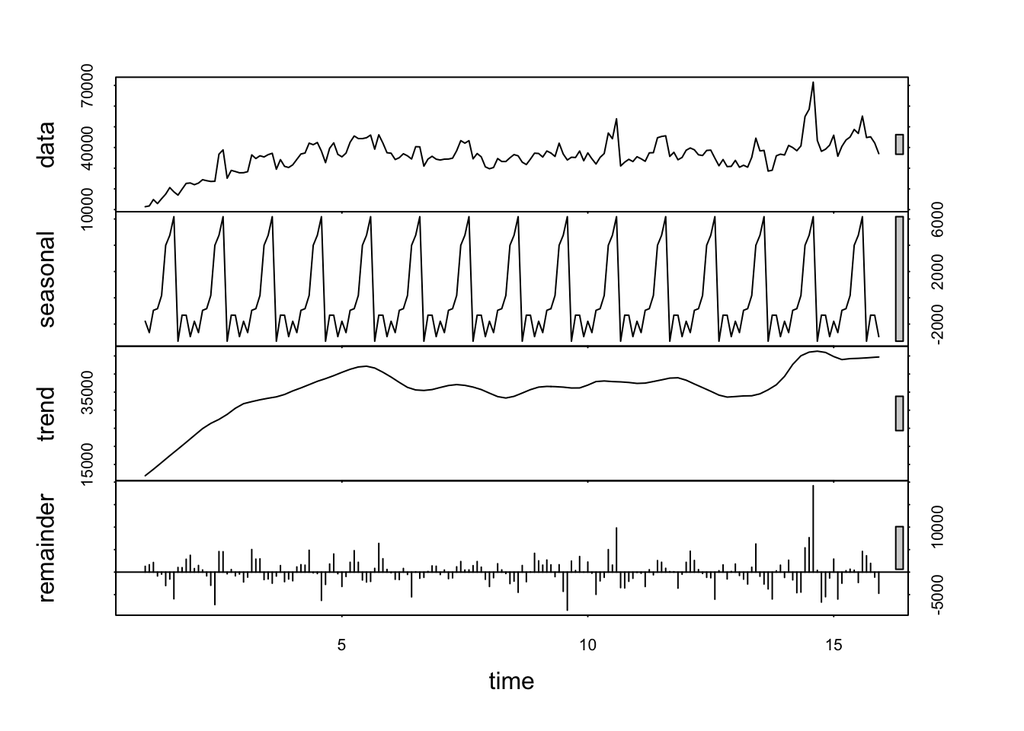

```r
library('forecast')
library('tseries')

# create a time series for the monthly moving average
count_ma <- ts(posts_per_month_year$count, deltat = 1/12)
# create a seasonal decomposition of the time seires
decomp = stl(count_ma, s.window="periodic")
plot(decomp)
```

We can see from the exploratory graphs and from the trend graph above that posts increase over time and the seasonal graph shows a seasonal trend (as expected from the prior seasonal graphs). As above it shows the summer time highs and winter lows. #### Model Creation We are using the forecast package to automatically return the best ARIMA model.

```r
arima_model<-auto.arima(count_ma, seasonal=TRUE)
arima_model
```

```
## Series: count_ma
## ARIMA(1,1,1)(0,0,2)[12]
##
## Coefficients:
##          ar1      ma1    sma1    sma2
##       0.5583  -0.8710  0.4125  0.1184
## s.e.  0.1059   0.0648  0.0780  0.0679
##
## sigma^2 estimated as 18290645:  log likelihood=-1749.78
## AIC=3509.55   AICc=3509.9   BIC=3525.49
```

We can see auto.arima chose to use parameters (1,1,1) which means the model uses a differencing degree of 1 (the number of times the data has had past values subctracted which in this case eliminates the increasing trend and establishes stationarity), an autoregresssive term of first lag (use previous period to predict the next period) and a moving average model of order 1. The next group of parameters selected are for the seasonality componenet which suggest the differencing degree is 0, the lag is 0 and the model is of order 2 (used in the forecast formula). https://en.wikipedia.org/wiki/Autoregressive_integrated_moving_average #### Forecast

```r
# forecast 12 months forward
fcast <- forecast(arima_model, h=12)
fcast
```

```
##        Point Forecast    Lo 80    Hi 80    Lo 95    Hi 95
## Jan 16       41151.40 35670.51 46632.28 32769.11 49533.68
## Feb 16       38018.89 31368.29 44669.49 27847.68 48190.11
## Mar 16       40680.78 33460.87 47900.69 29638.88 51722.68
## Apr 16       42356.42 34786.32 49926.52 30778.95 53933.89
## May 16       42911.08 35086.95 50735.21 30945.11 54877.05
## Jun 16       43549.46 35518.49 51580.43 31267.16 55831.77
## Jul 16       42802.53 34589.87 51015.19 30242.35 55362.71
## Aug 16       45544.07 37164.13 53924.01 32728.05 58360.08
## Sep 16       42999.89 34461.55 51538.23 29941.62 56058.15
## Oct 16       43470.36 34779.54 52161.19 30178.90 56761.83
## Nov 16       41955.52 33116.50 50794.54 28437.40 55473.64
## Dec 16       39706.02 30722.14 48689.89 25966.37 53445.67
```

#### Forecast Plot

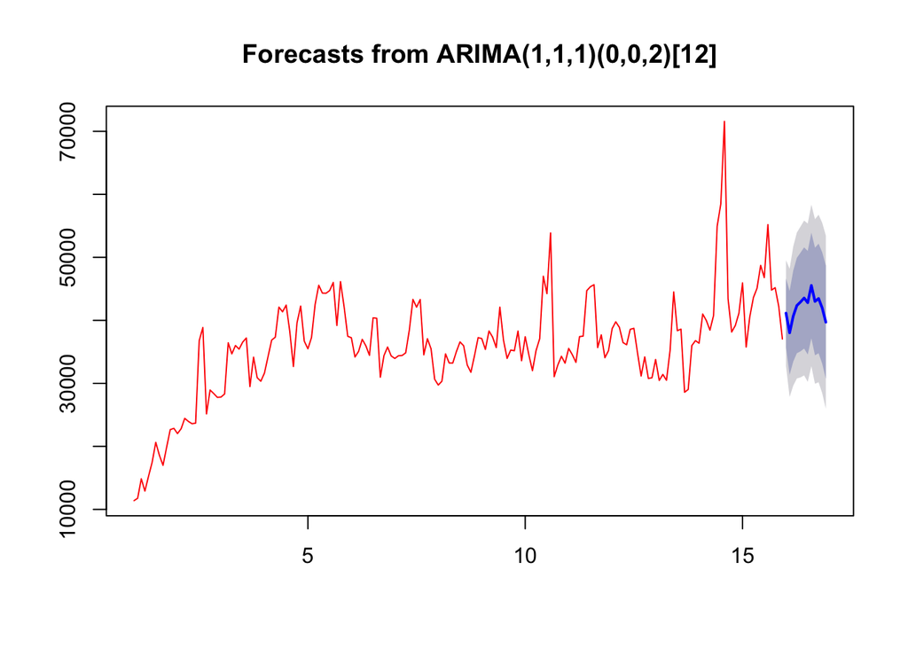

```r
plot(fcast, col="red")
```

#### Evaluation From the print out of the values of fcast above we can see it generally follows the seasonality componenets that we saw from the exploratory graphs above. We see a high in August and a low in February and appropriate trends leading up to and leaving this months as we previously saw.

```r
accuracy(fcast)
```

```
##                    ME     RMSE      MAE       MPE     MAPE      MASE
## Training set 365.9051 4216.939 2874.845 0.5512521 7.948284 0.5294682
##                     ACF1
## Training set 0.004276277
```

The ARIMA model gives a Mean Percentage Error of .55% which is low (signifying a good fit).

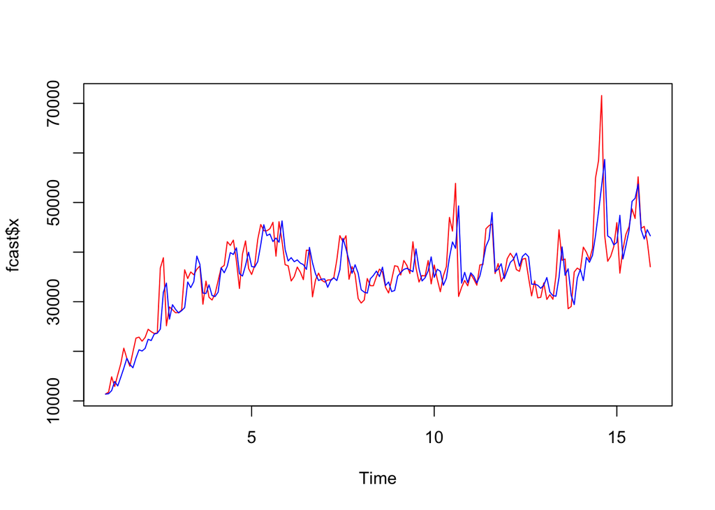

```r
plot(fcast$x, col="red")
lines(fitted(fcast), col="blue")
```

This graph shows the original data in red overlayed with the model prediction in blue representing a very close fit which supports our previous observations of a low MPE. The ARIMA model parameters that were chosen to be best use a lag term of 1 which in this case means it uses the previous months data to predict the next time slot. Thats why when there are big spikes in usage the ARIMA model doesn’t reflect that until the next months data point. This is a weakness of the model and does not allow it to make very far future predictions as the farther it makes predictions the less noisy the data will become and the more it will approach a constant value.

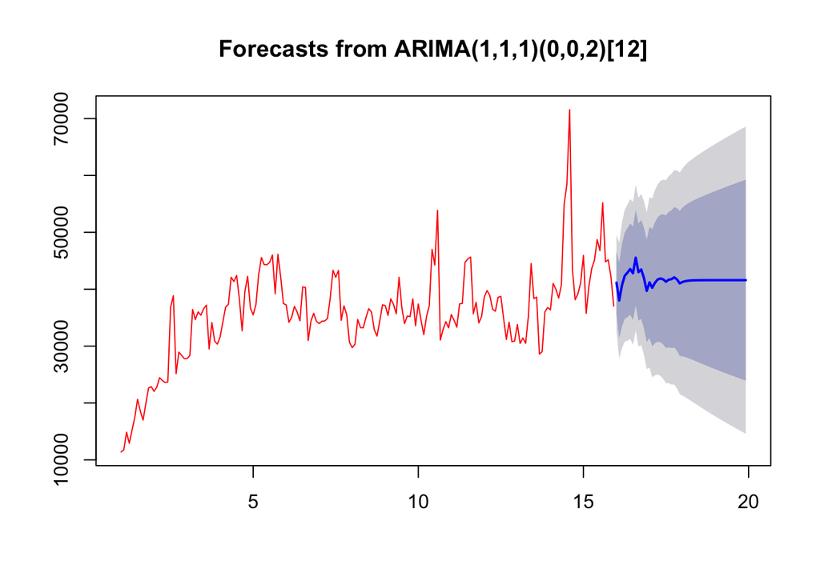

```r
fcast_far <- forecast(arima_model, h=48)
plot(fcast_far, col="red")
```